# Data Analysis on world wide Covid Vaccination

What data have you chosen?(Chosen Dataset, Source of dataset, Description of dataset, basic commands to describe dataset)  
**Dataset Chosen:** Day - by - day world wide covid-19 Vaccination Progress  
**Source of dataset:** https://www.kaggle.com/  
**Description of dataset:**

This is a dataset on the Covid-19 all over the world, including all the data of 190 countries from 24-02-2020 to 01-09-2021. This csv file contains 113605 rows and 62 columns. Each row corresponds to day - by - day covid situation of each country.

Load Packages

```r
library(knitr)
library(kableExtra)
library(ggplot2)
library(dplyr)
library(cowplot)
library(tidyr)
library(ggcorrplot)
library(tidyverse)
library(ggpubr)
```

Load Dataset

```r
mydata = read.csv("F:/Dataanalytics_theory/owid-covid-data.csv")
```

Removing Unwanted Attributes

```r
df = subset(mydata,select = -c(new_cases_smoothed,new_deaths_smoothed,new_cases_smoothed_per_million,new_deaths_smoothed_per_million,reproduction_rate,icu_patients,icu_patients_per_million,hosp_patients,hosp_patients_per_million,weekly_icu_admissions,weekly_icu_admissions_per_million,weekly_hosp_admissions,weekly_hosp_admissions_per_million,total_tests_per_thousand,new_tests_per_thousand,new_tests_smoothed,new_tests_smoothed_per_thousand,positive_rate,tests_per_case,tests_units,total_boosters,new_vaccinations_smoothed,total_boosters_per_hundred,new_vaccinations_smoothed_per_million,hospital_beds_per_thousand,excess_mortality,new_tests,total_tests,population_density,gdp_per_capita))
df<-df[!grepl("OWID",df$iso_code),]
newdf = data.frame(df)
#converting all rows to positive
d1<-subset(newdf,select = -c(iso_code,continent,location,date))
d2<-abs(d1)
d3<-subset(newdf,select = c(iso_code,continent,location,date))
newdf<-cbind(d3,d2)
```

Basic commands to describe dataset

```r
kable(head(newdf), "html") %>% kable_styling("striped") %>% scroll_box(width = "100%")
```

| iso_code | continent | location | date | total_cases | new_cases | total_deaths | new_deaths | total_cases_per_million | new_cases_per_million | total_deaths_per_million | new_deaths_per_million | total_vaccinations | people_vaccinated | people_fully_vaccinated | new_vaccinations | total_vaccinations_per_hundred | people_vaccinated_per_hundred | people_fully_vaccinated_per_hundred | stringency_index | population | median_age | aged_65_older | aged_70_older | extreme_poverty | cardiovasc_death_rate | diabetes_prevalence | female_smokers | male_smokers | handwashing_facilities | … |
| --- | --- | --- | --- | --- | --- | --- | --- | --- | --- | --- | --- | --- | --- | --- | --- | --- | --- | --- | --- | --- | --- | --- | --- | --- | --- | --- | --- | --- | --- | --- |
| AFG | Asia | Afghanistan | 2020-02-24 | 1 | 1 | NA | NA | 0.025 | 0.025 | NA | NA | NA | NA | NA | NA | NA | NA | NA | 8.33 | 39835428 | 18.6 | 2.581 | 1.337 | NA | 597.029 | 9.59 | NA | NA | 37.746 | … |
| AFG | Asia | Afghanistan | 2020-02-25 | 1 | 0 | NA | NA | 0.025 | 0.000 | NA | NA | NA | NA | NA | NA | NA | NA | NA | 8.33 | 39835428 | 18.6 | 2.581 | 1.337 | NA | 597.029 | 9.59 | NA | NA | 37.746 | … |
| AFG | Asia | Afghanistan | 2020-02-26 | 1 | 0 | NA | NA | 0.025 | 0.000 | NA | NA | NA | NA | NA | NA | NA | NA | NA | 8.33 | 39835428 | 18.6 | 2.581 | 1.337 | NA | 597.029 | 9.59 | NA | NA | 37.746 | … |
| AFG | Asia | Afghanistan | 2020-02-27 | 1 | 0 | NA | NA | 0.025 | 0.000 | NA | NA | NA | NA | NA | NA | NA | NA | NA | 8.33 | 39835428 | 18.6 | 2.581 | 1.337 | NA | 597.029 | 9.59 | NA | NA | 37.746 | … |
| AFG | Asia | Afghanistan | 2020-02-28 | 1 | 0 | NA | NA | 0.025 | 0.000 | NA | NA | NA | NA | NA | NA | NA | NA | NA | 8.33 | 39835428 | 18.6 | 2.581 | 1.337 | NA | 597.029 | 9.59 | NA | NA | 37.746 | … |
| AFG | Asia | Afghanistan | 2020-02-29 | 1 | 0 | NA | NA | 0.025 | 0.000 | NA | NA | NA | NA | NA | NA | NA | NA | NA | 8.33 | 39835428 | 18.6 | 2.581 | 1.337 | NA | 597.029 | 9.59 | NA | NA | 37.746 | … |

```r
dim(newdf)
```

```
## [1] 107647     32
```

```r
colnames(newdf)
```

```
##  [1] "iso_code"                            "continent"
##  [3] "location"                            "date"
##  [5] "total_cases"                         "new_cases"
##  [7] "total_deaths"                        "new_deaths"
##  [9] "total_cases_per_million"             "new_cases_per_million"
## [11] "total_deaths_per_million"            "new_deaths_per_million"
## [13] "total_vaccinations"                  "people_vaccinated"
## [15] "people_fully_vaccinated"             "new_vaccinations"
## [17] "total_vaccinations_per_hundred"      "people_vaccinated_per_hundred"
## [19] "people_fully_vaccinated_per_hundred" "stringency_index"
## [21] "population"                          "median_age"
## [23] "aged_65_older"                       "aged_70_older"
## [25] "extreme_poverty"                     "cardiovasc_death_rate"
## [27] "diabetes_prevalence"                 "female_smokers"
## [29] "male_smokers"                        "handwashing_facilities"
## [31] "life_expectancy"                     "human_development_index"
```

```r
typeof(newdf)
```

```
## [1] "list"
```

```r
class(newdf)
```

```
## [1] "data.frame"
```

```r
str(newdf)
```

```
## 'data.frame':    107647 obs. of  32 variables:
##  $ iso_code                           : chr  "AFG" "AFG" "AFG" "AFG" ...
##  $ continent                          : chr  "Asia" "Asia" "Asia" "Asia" ...
##  $ location                           : chr  "Afghanistan" "Afghanistan" "Afghanistan" "Afghanistan" ...
##  $ date                               : chr  "2020-02-24" "2020-02-25" "2020-02-26" "2020-02-27" ...
##  $ total_cases                        : num  1 1 1 1 1 1 1 1 2 4 ...
##  $ new_cases                          : num  1 0 0 0 0 0 0 0 1 2 ...
##  $ total_deaths                       : num  NA NA NA NA NA NA NA NA NA NA ...
##  $ new_deaths                         : num  NA NA NA NA NA NA NA NA NA NA ...
##  $ total_cases_per_million            : num  0.025 0.025 0.025 0.025 0.025 0.025 0.025 0.025 0.05 0.1 ...
##  $ new_cases_per_million              : num  0.025 0 0 0 0 0 0 0 0.025 0.05 ...
##  $ total_deaths_per_million           : num  NA NA NA NA NA NA NA NA NA NA ...
##  $ new_deaths_per_million             : num  NA NA NA NA NA NA NA NA NA NA ...
##  $ total_vaccinations                 : num  NA NA NA NA NA NA NA NA NA NA ...
##  $ people_vaccinated                  : num  NA NA NA NA NA NA NA NA NA NA ...
```

[output cut: 18 more lines]

```r
summary(newdf)
```

```
##    iso_code          continent           location             date
##  Length:107647      Length:107647      Length:107647      Length:107647
##  Class :character   Class :character   Class :character   Class :character
##  Mode  :character   Mode  :character   Mode  :character   Mode  :character
##
##
##
##
##   total_cases         new_cases       total_deaths      new_deaths
##  Min.   :       1   Min.   :     0   Min.   :     1   Min.   :   0.00
##  1st Qu.:    1597   1st Qu.:     2   1st Qu.:    60   1st Qu.:   0.00
##  Median :   15358   Median :    74   Median :   434   Median :   2.00
##  Mean   :  432557   Mean   :  2126   Mean   : 11211   Mean   :  49.08
##  3rd Qu.:  154929   3rd Qu.:   727   3rd Qu.:  3833   3rd Qu.:  14.00
##  Max.   :39396156   Max.   :414188   Max.   :642081   Max.   :7374.00
##  NA's   :4957       NA's   :4965     NA's   :15346    NA's   :15349
##  total_cases_per_million new_cases_per_million total_deaths_per_million
##  Min.   :     0.0        Min.   :   0.000      Min.   :   0.001
##  1st Qu.:   297.1        1st Qu.:   0.200      1st Qu.:   9.045
##  Median :  2265.0        Median :   9.004      Median :  58.899
##  Mean   : 15940.9        Mean   :  79.946      Mean   : 335.392
##  3rd Qu.: 17617.1        3rd Qu.:  75.024      3rd Qu.: 382.036
##  Max.   :203498.1        Max.   :8620.690      Max.   :5944.199
##  NA's   :4957            NA's   :4965          NA's   :15346
##  new_deaths_per_million total_vaccinations  people_vaccinated
##  Min.   :  0.000        Min.   :0.000e+00   Min.   :0.000e+00
##  1st Qu.:  0.000        1st Qu.:1.711e+05   1st Qu.:1.400e+05
##  Median :  0.116        Median :1.220e+06   Median :8.411e+05
##  Mean   :  1.519        Mean   :1.842e+07   Mean   :7.851e+06
##  3rd Qu.:  1.234        3rd Qu.:6.854e+06   3rd Qu.:4.303e+06
##  Max.   :215.334        Max.   :2.076e+09   Max.   :1.072e+09
##  NA's   :15349          NA's   :85828       NA's   :86890
##  people_fully_vaccinated new_vaccinations   total_vaccinations_per_hundred
##  Min.   :        1       Min.   :       0   Min.   :  0.00
##  1st Qu.:    68828       1st Qu.:    4593   1st Qu.:  4.36
##  Median :   520041       Median :   24239   Median : 21.43
##  Mean   :  4853970       Mean   :  267545   Mean   : 38.49
##  3rd Qu.:  2756953       3rd Qu.:  110629   3rd Qu.: 62.45
##  Max.   :889439000       Max.   :24741000   Max.   :234.15
##  NA's   :89758           NA's   :89870      NA's   :85828
```

[output cut: 25 more lines]

```
##  Min.   : 0.10   Min.   : 7.70   Min.   :  1.19         Min.   :53.28
##  1st Qu.: 1.90   1st Qu.:21.60   1st Qu.: 19.35         1st Qu.:67.92
##  Median : 6.30   Median :31.40   Median : 49.54         Median :74.79
##  Mean   :10.62   Mean   :32.71   Mean   : 50.66         Mean   :73.25
##  3rd Qu.:19.30   3rd Qu.:41.30   3rd Qu.: 83.24         3rd Qu.:78.80
##  Max.   :44.00   Max.   :78.10   Max.   :100.00         Max.   :86.75
##  NA's   :29260   NA's   :30410   NA's   :57450          NA's   :432
##  human_development_index
##  Min.   :0.394
##  1st Qu.:0.602
##  Median :0.748
##  Mean   :0.727
##  3rd Qu.:0.848
##  Max.   :0.957
##  NA's   :7042
```

Data Cleaning  
**Iso code Column**  
Checking Null values

```r
newdf%>%
  summarise(countcode=sum(is.na(location)))
```

```
##   countcode
## 1         0
```

**Continent Column**  
checking Null values

```r
newdf%>%
  summarise(countcontinent=sum(is.na(continent)))
```

```
##   countcontinent
## 1              0
```

**Date Column**  
Checking Null Values

```r
newdf%>%
  summarise(countdate=sum(is.na(date)))
```

```
##   countdate
## 1         0
```

**Total Cases Column**  
Checking Null Values

```r
newdf%>%
  summarise(counttotal=sum(is.na(total_cases)))
```

```
##   counttotal
## 1       4957
```

Removing Records with Null Values

```r
newdf<-newdf[!is.na(newdf$total_cases),]
```

**New Cases Column**  
Checking Null Values

```r
newdf%>%
  summarise(countnew=sum(is.na(new_cases)))
```

```
##   countnew
## 1        8
```

Replacing Null Values with 0

```r
newdf <- newdf %>% mutate(new_cases = ifelse(is.na(new_cases),0,new_cases))
```

**Total Deaths Column**  
Checking Null Values

```r
newdf%>%
  summarise(countnew=sum(is.na(total_deaths)))
```

```
##   countnew
## 1    10390
```

Replacing Null Values With 0

```r
newdf <- newdf %>% mutate(total_deaths = ifelse(is.na(total_deaths),0,total_deaths))
```

**New Deaths Column**  
Checking Null Values

```r
newdf%>%
  summarise(countnew=sum(is.na(new_deaths)))
```

```
##   countnew
## 1    10393
```

Replacing Null Values with 0

```r
newdf <- newdf %>% mutate(new_deaths = ifelse(is.na(new_deaths),0,new_deaths))
```

**Population Column**  
Checking Null Values

```r
newdf%>%
  summarise(countnew=sum(is.na(population)))
```

```
##   countnew
## 1        0
```

Removing Null value Rows

```r
newdf<-newdf[!is.na(newdf$population),]
```

**Total Cases Per Million Column**  
Checking Null Values

```r
newdf%>%
  summarise(countnew=sum(is.na(total_cases_per_million)))
```

```
##   countnew
## 1        0
```

**New Cases Per Million Column**  
Checking Null Values

```r
newdf%>%
  summarise(countnew=sum(is.na(new_cases_per_million)))
```

```
##   countnew
## 1        8
```

Replacing Null Values with Per million Calculation

```r
newdf <- newdf %>% mutate(new_cases_per_million = ifelse(is.na(new_cases_per_million),((newdf$new_cases/newdf$population)*1000000),new_cases_per_million))
```

**Total Deaths Per Million Column**  
Checking Null Values

```r
newdf%>%
  summarise(countnew=sum(is.na(total_deaths_per_million)))
```

```
##   countnew
## 1    10390
```

Replacing Null Values with Per Million Population

```r
newdf <- newdf %>% mutate(total_deaths_per_million = ifelse(is.na(total_deaths_per_million),((newdf$total_deaths/newdf$population)*1000000),total_deaths_per_million))
```

**New Deaths Per Million Column**  
Checking Null Values

```r
newdf%>%
  summarise(countnew=sum(is.na(new_deaths_per_million)))
```

```
##   countnew
## 1    10393
```

Replacing Null Values with Per Million Calculation

```r
newdf <- newdf %>% mutate(new_deaths_per_million = ifelse(is.na(new_deaths_per_million),((newdf$new_deaths/newdf$population)*1000000),new_deaths_per_million))
```

**Total Vaccinations Column**  
Checking Null Values

```r
newdf%>%
  summarise(countnew=sum(is.na(total_vaccinations)))
```

```
##   countnew
## 1    82199
```

Replacing Null Values with 0

```r
newdf <- newdf %>% mutate(total_vaccinations = ifelse(is.na(total_vaccinations),0,total_vaccinations))
```

**People Vaccinated Column**  
Checking Null Values

```r
newdf%>%
  summarise(countnew=sum(is.na(people_vaccinated)))
```

```
##   countnew
## 1    83144
```

Replacing Null Values with 0.

```r
newdf <- newdf %>% mutate(people_vaccinated = ifelse(is.na(people_vaccinated),0,people_vaccinated))
```

**People Fully Vaccinated And New Vaccinations Columns**  
Checking Null Values

```r
newdf%>%
  summarise(countnew=sum(is.na(people_fully_vaccinated)))
```

```
##   countnew
## 1    85932
```

```r
newdf%>%
  summarise(countnew=sum(is.na(new_vaccinations)))
```

```
##   countnew
## 1    85668
```

Replacing Null Values with 0.

```r
newdf <- newdf %>% mutate(people_fully_vaccinated = ifelse(is.na(people_fully_vaccinated),0,people_fully_vaccinated))
newdf <- newdf %>% mutate(new_vaccinations = ifelse(is.na(new_vaccinations),0,new_vaccinations))
```

**Total Vaccinations Per Hundred, People Vaccinated per Hundered, People Fully vaccinated per hundred Columns**  
Checking Null Values

```r
newdf%>%
  summarise(countnew=sum(is.na(total_vaccinations_per_hundred)))
```

```
##   countnew
## 1    82199
```

```r
newdf%>%
  summarise(countnew=sum(is.na(people_vaccinated_per_hundred)))
```

```
##   countnew
## 1    83144
```

```r
newdf%>%
  summarise(countnew=sum(is.na(people_fully_vaccinated_per_hundred)))
```

```
##   countnew
## 1    85932
```

Replacing Null Values with per hundred calculation.

```r
newdf <- newdf %>% mutate(total_vaccinations_per_hundred = ifelse(is.na(total_vaccinations_per_hundred),((newdf$total_vaccinations/newdf$population)*100),total_vaccinations_per_hundred))
newdf <- newdf %>% mutate(people_vaccinated_per_hundred = ifelse(is.na(people_vaccinated_per_hundred),((newdf$people_vaccinated/newdf$population)*100),people_vaccinated_per_hundred))
newdf <- newdf %>% mutate(people_fully_vaccinated_per_hundred = ifelse(is.na(people_fully_vaccinated_per_hundred),((newdf$people_fully_vaccinated/newdf$population)*100),people_fully_vaccinated_per_hundred))
```

**Stringency Index Column**  
Checking Null Values

```r
newdf%>%
  summarise(countnew=sum(is.na(stringency_index)))
```

```
##   countnew
## 1    10480
```

Calculating Null values of stringency index by median

```r
newdf <- newdf %>% mutate(stringency_index=replace(stringency_index,is.na(stringency_index),median(stringency_index,na.rm = TRUE)))
newdf%>%
  summarise(countnew=sum(is.na(stringency_index)))
```

```
##   countnew
## 1        0
```

Checking null values for all other attributes and calculating the missing values with median of attributes.

```r
newdf%>%
  summarise(countnew=sum(is.na(median_age)))
```

```
##   countnew
## 1     4118
```

```r
newdf <- newdf %>% mutate(median_age=replace(median_age,is.na(median_age),median(median_age,na.rm = TRUE)))
newdf%>%
  summarise(countnew=sum(is.na(aged_65_older)))
```

```
##   countnew
## 1     5236
```

```r
newdf <- newdf %>% mutate(aged_65_older=replace(aged_65_older,is.na(aged_65_older),median(aged_65_older,na.rm = TRUE)))
newdf%>%
  summarise(countnew=sum(is.na(aged_70_older)))
```

```
##   countnew
## 1     4663
```

```r
newdf <- newdf %>% mutate(aged_70_older=replace(aged_70_older,is.na(aged_70_older),median(aged_70_older,na.rm = TRUE)))
newdf%>%
  summarise(countnew=sum(is.na(extreme_poverty)))
```

```
##   countnew
## 1    36304
```

```r
newdf <- newdf %>% mutate(extreme_poverty=replace(extreme_poverty,is.na(extreme_poverty),median(extreme_poverty,na.rm = TRUE)))
newdf%>%
  summarise(countnew=sum(is.na(cardiovasc_death_rate)))
```

```
##   countnew
## 1     3319
```

```r
newdf <- newdf %>% mutate(cardiovasc_death_rate=replace(cardiovasc_death_rate,is.na(cardiovasc_death_rate),median(cardiovasc_death_rate,na.rm = TRUE)))
newdf%>%
  summarise(countnew=sum(is.na(diabetes_prevalence)))
```

```
##   countnew
## 1     1663
```

```r
newdf <- newdf %>% mutate(diabetes_prevalence=replace(diabetes_prevalence,is.na(diabetes_prevalence),median(diabetes_prevalence,na.rm = TRUE)))
newdf%>%
  summarise(countnew=sum(is.na(female_smokers)))
```

```
##   countnew
## 1    25075
```

```r
newdf <- newdf %>% mutate(female_smokers=replace(female_smokers,is.na(female_smokers),median(female_smokers,na.rm = TRUE)))
newdf%>%
  summarise(countnew=sum(is.na(male_smokers)))
```

```
##   countnew
## 1    26160
```

```r
newdf <- newdf %>% mutate(male_smokers=replace(male_smokers,is.na(male_smokers),median(male_smokers,na.rm = TRUE)))

newdf%>%
  summarise(countnew=sum(is.na(handwashing_facilities)))
```

```
##   countnew
## 1    52656
```

```r
newdf <- newdf %>% mutate(handwashing_facilities=replace(handwashing_facilities,is.na(handwashing_facilities),median(handwashing_facilities,na.rm = TRUE)))
newdf%>%
  summarise(countnew=sum(is.na(life_expectancy)))
```

```
##   countnew
## 1        0
```

```r
newdf <- newdf %>% mutate(life_expectancy=replace(life_expectancy,is.na(life_expectancy),median(life_expectancy,na.rm = TRUE)))
newdf%>%
  summarise(countnew=sum(is.na(human_development_index)))
```

```
##   countnew
## 1     2771
```

```r
newdf <- newdf %>% mutate(human_development_index=replace(human_development_index,is.na(human_development_index),median(human_development_index,na.rm = TRUE)))
```

**Data after completion of cleaning**

```r
kable(head(newdf), "html") %>% kable_styling("striped") %>% scroll_box(width = "100%")
```

| iso_code | continent | location | date | total_cases | new_cases | total_deaths | new_deaths | total_cases_per_million | new_cases_per_million | total_deaths_per_million | new_deaths_per_million | total_vaccinations | people_vaccinated | people_fully_vaccinated | new_vaccinations | total_vaccinations_per_hundred | people_vaccinated_per_hundred | people_fully_vaccinated_per_hundred | stringency_index | population | median_age | aged_65_older | aged_70_older | extreme_poverty | cardiovasc_death_rate | diabetes_prevalence | female_smokers | male_smokers | handwashing_facilities | … |
| --- | --- | --- | --- | --- | --- | --- | --- | --- | --- | --- | --- | --- | --- | --- | --- | --- | --- | --- | --- | --- | --- | --- | --- | --- | --- | --- | --- | --- | --- | --- |
| AFG | Asia | Afghanistan | 2020-02-24 | 1 | 1 | 0 | 0 | 0.025 | 0.025 | 0 | 0 | 0 | 0 | 0 | 0 | 0 | 0 | 0 | 8.33 | 39835428 | 18.6 | 2.581 | 1.337 | 2.2 | 597.029 | 9.59 | 6.2 | 31.4 | 37.746 | … |
| AFG | Asia | Afghanistan | 2020-02-25 | 1 | 0 | 0 | 0 | 0.025 | 0.000 | 0 | 0 | 0 | 0 | 0 | 0 | 0 | 0 | 0 | 8.33 | 39835428 | 18.6 | 2.581 | 1.337 | 2.2 | 597.029 | 9.59 | 6.2 | 31.4 | 37.746 | … |
| AFG | Asia | Afghanistan | 2020-02-26 | 1 | 0 | 0 | 0 | 0.025 | 0.000 | 0 | 0 | 0 | 0 | 0 | 0 | 0 | 0 | 0 | 8.33 | 39835428 | 18.6 | 2.581 | 1.337 | 2.2 | 597.029 | 9.59 | 6.2 | 31.4 | 37.746 | … |
| AFG | Asia | Afghanistan | 2020-02-27 | 1 | 0 | 0 | 0 | 0.025 | 0.000 | 0 | 0 | 0 | 0 | 0 | 0 | 0 | 0 | 0 | 8.33 | 39835428 | 18.6 | 2.581 | 1.337 | 2.2 | 597.029 | 9.59 | 6.2 | 31.4 | 37.746 | … |
| AFG | Asia | Afghanistan | 2020-02-28 | 1 | 0 | 0 | 0 | 0.025 | 0.000 | 0 | 0 | 0 | 0 | 0 | 0 | 0 | 0 | 0 | 8.33 | 39835428 | 18.6 | 2.581 | 1.337 | 2.2 | 597.029 | 9.59 | 6.2 | 31.4 | 37.746 | … |
| AFG | Asia | Afghanistan | 2020-02-29 | 1 | 0 | 0 | 0 | 0.025 | 0.000 | 0 | 0 | 0 | 0 | 0 | 0 | 0 | 0 | 0 | 8.33 | 39835428 | 18.6 | 2.581 | 1.337 | 2.2 | 597.029 | 9.59 | 6.2 | 31.4 | 37.746 | … |

**Exploratory Data Analysis**  
Total Cases per country

```r
a<-newdf %>%
  group_by(location)%>%
  summarise(vaccine_tally=sum(new_cases))%>%
  arrange(desc(vaccine_tally))%>%
  mutate(location=reorder(location,vaccine_tally))%>%
  top_n(15)
```

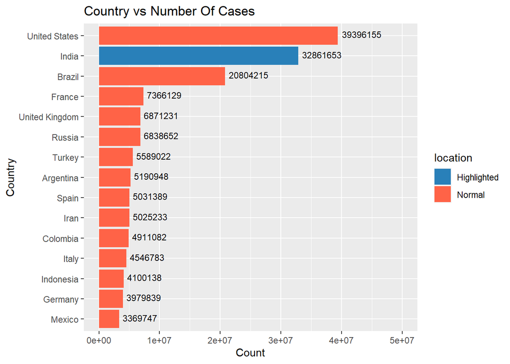

```r
b<-data.frame(a)
p<-ggplot(b,aes(x=location,y=vaccine_tally,fill=factor(ifelse(location=="India","Highlighted","Normal"))))+geom_bar(stat='identity')+
  scale_fill_manual(name = "location", values=c("#2980b9","tomato"))+
  geom_text(aes(label=vaccine_tally), vjust=0.3,hjust=-0.1, color="black", size=3.0)+
  coord_flip(ylim = c(0, 50000000))
p<-p + ggtitle("Country vs Number Of Cases") +
  xlab("Country") + ylab("Count")
p
```

**Inference:**  
1. United states, India, Brazil are the top 3 most effected countries in the world due to covid.  
World Map Showing Cases in Countries

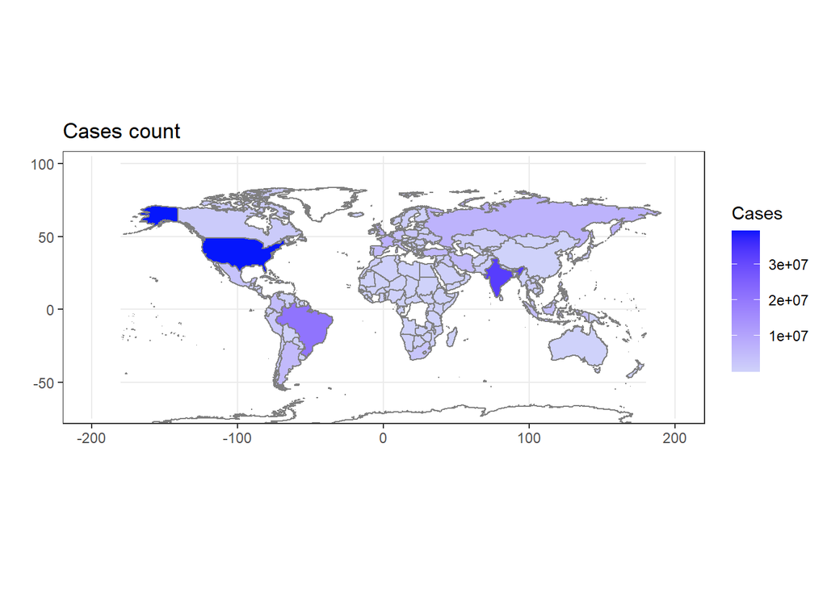

```r
newdf$location[newdf$location=="United States"]<-"USA"
newdf$location[newdf$location=="United Kingdom"]<-"UK"
WorldData <- map_data('world') %>% fortify
goldc <- newdf%>%
  group_by(location)%>%
  summarise(vaccine_tally=sum(new_cases))
ggplot() +
  geom_map(data = WorldData, map = WorldData,
           aes(x = long, y = lat, group = group, map_id=region),
           fill = "white", colour = "#7f7f7f", size=0.5) +
  geom_map(data = goldc, map=WorldData,
           aes(fill=vaccine_tally, map_id=location),
           colour="#7f7f7f", size=0.5) +
  coord_map("rectangular", lat0=0, xlim=c(-200,200), ylim=c(-70, 100)) +
  scale_fill_continuous(low="#cfd2fa", high="#0516fc", guide="colorbar") +
  labs(fill="Cases", title="Cases count", x="", y="") +
  theme_bw()
```

Month wise cases in top-4 effected countries.

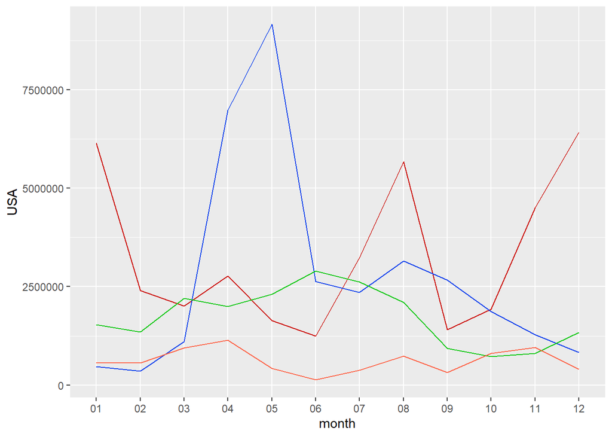

```r
datedf<-newdf[, c('date', 'new_cases','location')]
datedf$month <- format(as.Date(datedf$date), "%m")
usadf<-subset(datedf,location=="USA")
indiadf<-subset(datedf,location=="India")
brazildf<-subset(datedf,location=="Brazil")
francedf<-subset(datedf,location=="France")
usa<-usadf %>%
  group_by(month)%>%
  summarise(USA=sum(new_cases))
usa1<-data.frame(usa)
india<-indiadf %>%
  group_by(month)%>%
  summarise(India=sum(new_cases))
india1<-data.frame(india)
colnames(india1) <- c('month1','India')
brazil<-brazildf %>%
  group_by(month)%>%
  summarise(Brazil=sum(new_cases))
brazil1<-data.frame(brazil)
colnames(brazil1) <- c('month2','Brazil')
france<-francedf %>%
  group_by(month)%>%
  summarise(france=sum(new_cases))
france1<-data.frame(france)
colnames(france1) <- c('month3','France')
full<-cbind(usa1,india1,brazil1,france1)

ggplot(full, aes(x=month)) +
  geom_line(aes(y = USA), color = "#cc0d06",group=1) +
  geom_line(aes(y = India), color="#093fed",group=1) +
  geom_line(aes(y = Brazil), color="#04c70a",group=1) +
  geom_line(aes(y = France), color="tomato",group=1)
```

```r
a<-newdf %>%
  group_by(location)%>%
  summarise(vaccine_tally=sum(new_deaths))%>%
  arrange(desc(vaccine_tally))%>%
  mutate(location=reorder(location,vaccine_tally))%>%
  top_n(15)
```

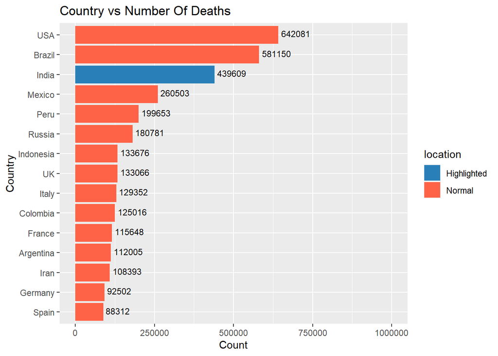

```r
b<-data.frame(a)
p<-ggplot(b,aes(x=location,y=vaccine_tally,fill=factor(ifelse(location=="India","Highlighted","Normal"))))+geom_bar(stat='identity')+
  scale_fill_manual(name = "location", values=c("#2980b9","tomato"))+
  geom_text(aes(label=vaccine_tally), vjust=0.3,hjust=-0.1, color="black", size=3.0)+
  coord_flip(ylim = c(0, 1000000))
p<-p + ggtitle("Country vs Number Of Deaths") +
  xlab("Country") + ylab("Count")
p
```

**Inference:**  
1. USA, Brazil, India are the top-3 countries in deaths caused due to Covid-19.  
2. Compared between cases top-15 and deaths top-15, PERU was not present in top-3 of cases but present at top-5 in deaths.  
3. Turkey has the lowest death rate even though it present in 7th place of cases, it was not present in the top-15 of deaths  
World Map Showing Deaths in Countries

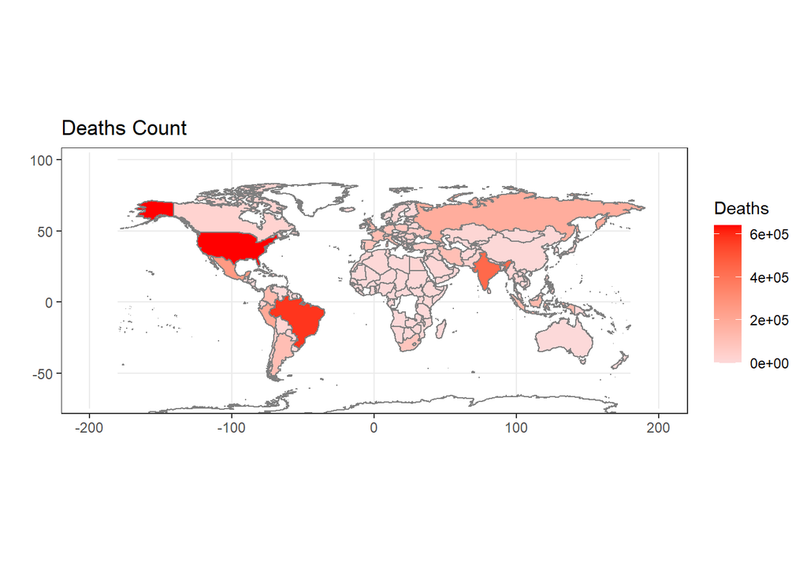

```r
newdf$location[newdf$location=="United States"]<-"USA"
newdf$location[newdf$location=="United Kingdom"]<-"UK"
WorldData <- map_data('world') %>% fortify
goldc <- newdf%>%
  group_by(location)%>%
  summarise(vaccine_tally=sum(new_deaths))
ggplot() +
  geom_map(data = WorldData, map = WorldData,
           aes(x = long, y = lat, group = group, map_id=region),
           fill = "white", colour = "#7f7f7f", size=0.5) +
  geom_map(data = goldc, map=WorldData,
           aes(fill=vaccine_tally, map_id=location),
           colour="#7f7f7f", size=0.5) +
  coord_map("rectangular", lat0=0, xlim=c(-200,200), ylim=c(-70, 100)) +
  scale_fill_continuous(low="#fcd9d9", high="#ff0000", guide="colorbar") +
  labs(fill="Deaths", title="Deaths Count", x="", y="") +
  theme_bw()
```

Month wise deaths in top-4 effected countries.

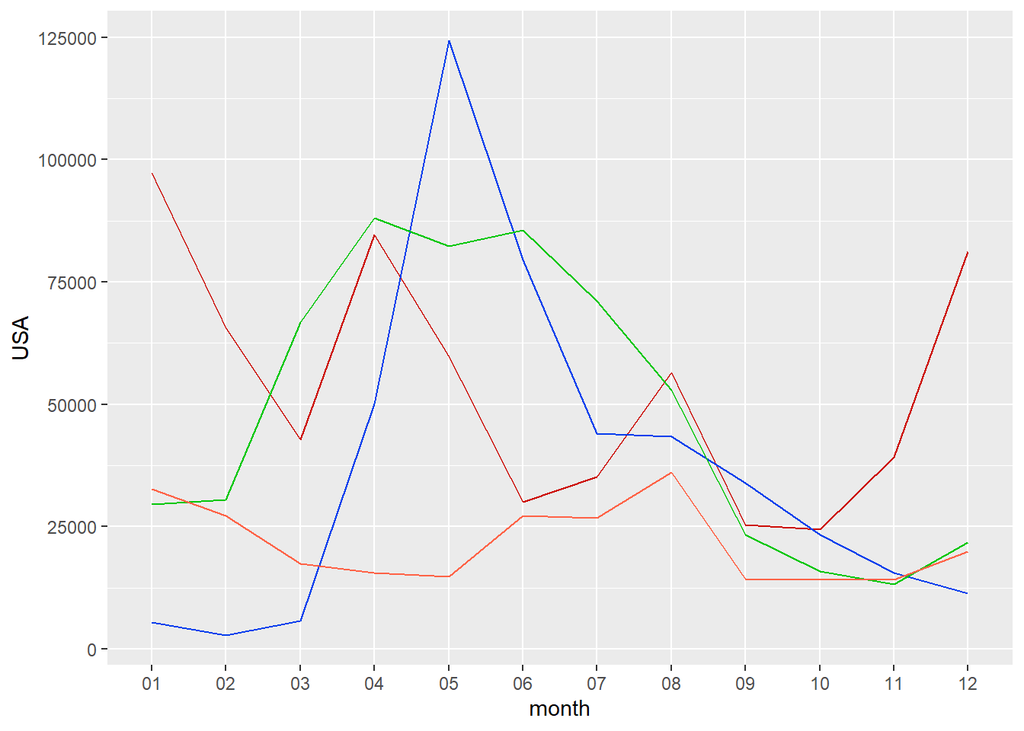

```r
datedf<-newdf[, c('date', 'new_deaths','location')]
datedf$month <- format(as.Date(datedf$date), "%m")
usadf<-subset(datedf,location=="USA")
indiadf<-subset(datedf,location=="India")
brazildf<-subset(datedf,location=="Brazil")
mexicodf<-subset(datedf,location=="Mexico")
usa<-usadf %>%
  group_by(month)%>%
  summarise(USA=sum(new_deaths))
usa1<-data.frame(usa)
india<-indiadf %>%
  group_by(month)%>%
  summarise(India=sum(new_deaths))
india1<-data.frame(india)
colnames(india1) <- c('month1','India')
brazil<-brazildf %>%
  group_by(month)%>%
  summarise(Brazil=sum(new_deaths))
brazil1<-data.frame(brazil)
colnames(brazil1) <- c('month2','Brazil')
mexico<-mexicodf %>%
  group_by(month)%>%
  summarise(mexico=sum(new_deaths))
mexico1<-data.frame(mexico)
colnames(mexico1) <- c('month3','Mexico')
full<-cbind(usa1,india1,brazil1,mexico1)

ggplot(full, aes(x=month)) +
  geom_line(aes(y = USA), color = "#cc0d06",group=1) +
  geom_line(aes(y = India), color="#093fed",group=1) +
  geom_line(aes(y = Brazil), color="#04c70a",group=1) +
  geom_line(aes(y = Mexico), color="tomato",group=1)
```

Total Vaccinations per country

```r
a<-newdf %>%
  group_by(location)%>%
  summarise(vaccine_tally=sum(new_vaccinations))%>%
  arrange(desc(vaccine_tally))%>%
  mutate(location=reorder(location,vaccine_tally))%>%
  top_n(15)
```

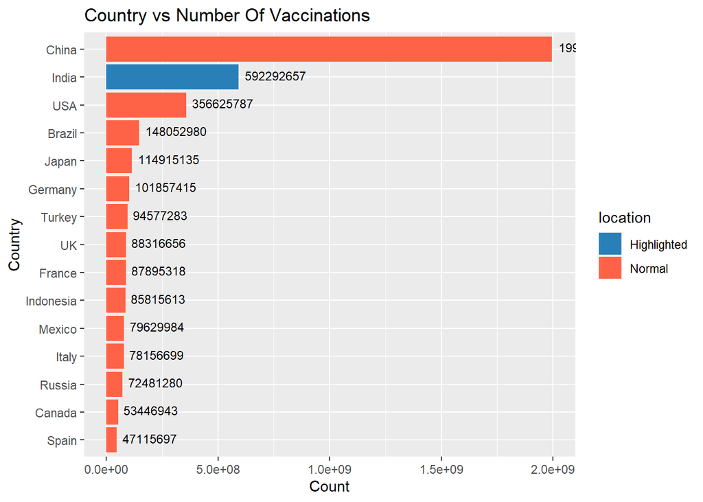

```r
b<-data.frame(a)
p<-ggplot(b,aes(x=location,y=vaccine_tally,fill=factor(ifelse(location=="India","Highlighted","Normal"))))+geom_bar(stat='identity')+
  scale_fill_manual(name = "location", values=c("#2980b9","tomato"))+
  geom_text(aes(label=vaccine_tally), vjust=0.3,hjust=-0.1, color="black", size=3.0)+
  coord_flip(ylim = c(0, 2000000000))
p<-p + ggtitle("Country vs Number Of Vaccinations") +
  xlab("Country") + ylab("Count")
p
```

**Inference:**  
1. Top 5 countries in vaccinations are China, India, USA, Brazil and Japan.  
2. Even though UK and Russia have their own vaccinations they placed below brazil, japan etc… this is because lack of influence in the country.  
World Map Showing Vaccination in Countries

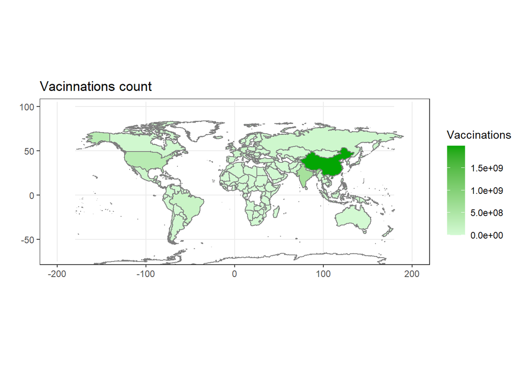

```r
newdf$location[newdf$location=="United States"]<-"USA"
newdf$location[newdf$location=="United Kingdom"]<-"UK"
WorldData <- map_data('world') %>% fortify
goldc <- newdf%>%
  group_by(location)%>%
  summarise(vaccine_tally=sum(new_vaccinations))
ggplot() +
  geom_map(data = WorldData, map = WorldData,
           aes(x = long, y = lat, group = group, map_id=region),
           fill = "white", colour = "#7f7f7f", size=0.5) +
  geom_map(data = goldc, map=WorldData,
           aes(fill=vaccine_tally, map_id=location),
           colour="#7f7f7f", size=0.5) +
  coord_map("rectangular", lat0=0, xlim=c(-200,200), ylim=c(-70, 100)) +
  scale_fill_continuous(low="#d4fad4", high="#03a603", guide="colorbar") +
  labs(fill="Vaccinations", title="Vacinnations count", x="", y="") +
  theme_bw()
```

Are countries doing vaccination enough

```r
cal<-newdf
cal$new_vaccinations_per_million <- ((cal$new_vaccinations/newdf$population)*1000000)
a<-cal %>%
  group_by(location)%>%
  summarise(vaccine_tally=sum(new_vaccinations_per_million))%>%
  arrange(desc(vaccine_tally))%>%
  mutate(location=reorder(location,vaccine_tally))%>%
  top_n(15)
```

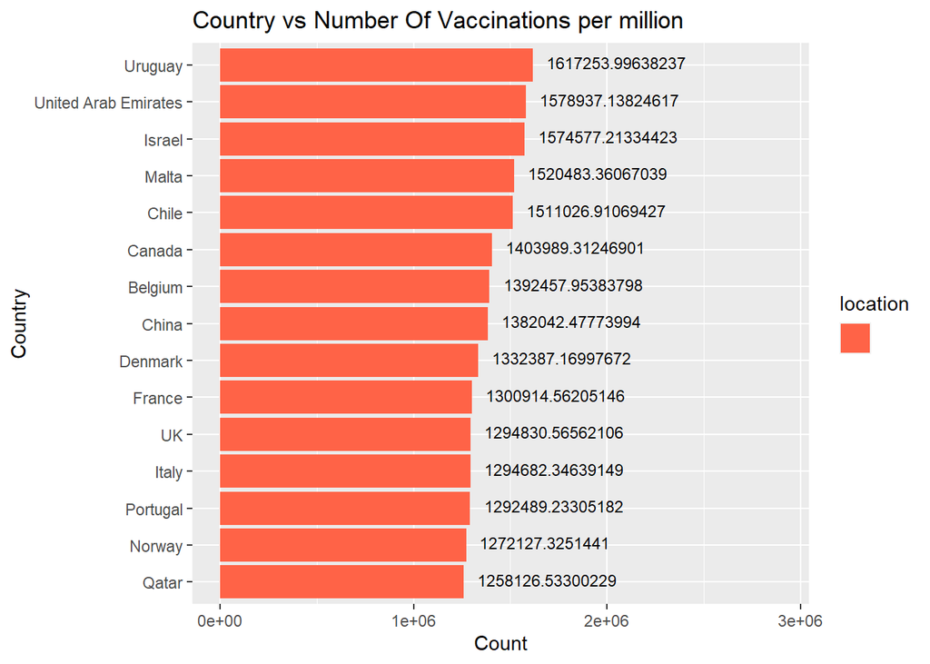

```r
indiarank<-cal %>%
  group_by(location)%>%
  summarise(vaccine_tally=sum(new_vaccinations_per_million))%>%
  arrange(desc(vaccine_tally))%>%
  mutate(location=reorder(location,vaccine_tally))
permillion<-data.frame(a)
p<-ggplot(permillion,aes(x=location,y=vaccine_tally,fill=""))+geom_bar(stat='identity')+scale_fill_manual(name = "location", values=c("tomato"))+
  geom_text(aes(label=vaccine_tally), vjust=0.3,hjust=-0.1, color="black", size=3.0)+
  coord_flip(ylim = c(0, 2900000))
p<-p + ggtitle("Country vs Number Of Vaccinations per million") +
  xlab("Country") + ylab("Count")
p
```

```r
print('Rank of india')
```

```
## [1] "Rank of india"
```

```r
which(grepl("India", indiarank$location))
```

```
## [1] 70
```

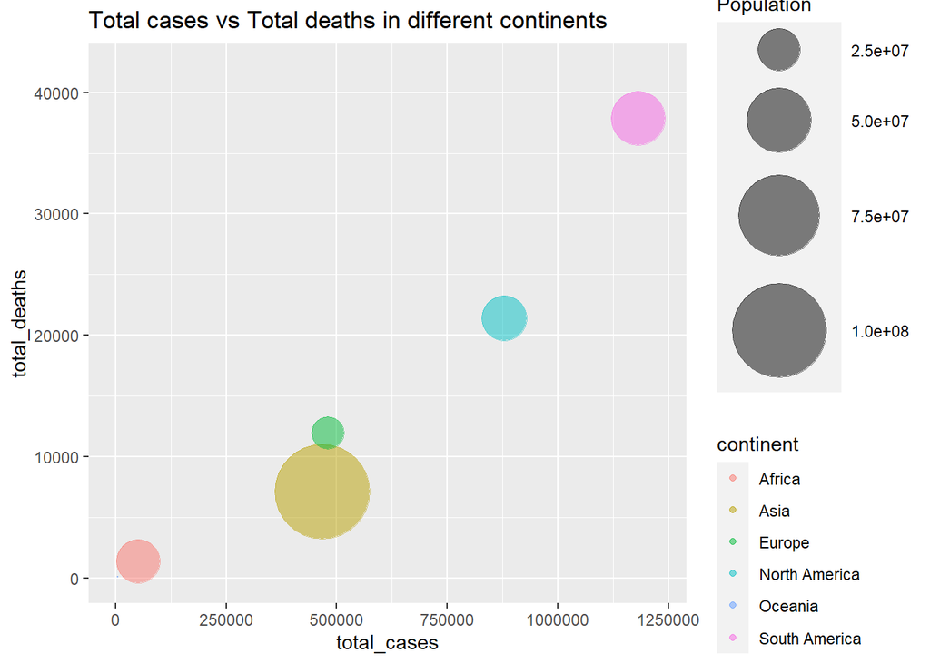

```r
df1<-newdf %>%
  group_by(continent) %>%
  summarise_at(vars(population,total_cases,total_deaths),list(mean))
g1 <-df1 %>%
  arrange(desc(population)) %>%
  mutate(continent=factor(continent)) %>%
  ggplot(aes(x=total_cases,y=total_deaths,size=population,color=continent))+
  geom_point(alpha=0.5) +xlim(0,1230000)+ylim(0,42000)+
  scale_size(range=c(.01,24),name="Population")+
  labs(title="Total cases vs Total deaths in different continents")
g1
```

Covid-19 Cases in Top-5 Developed Countries.

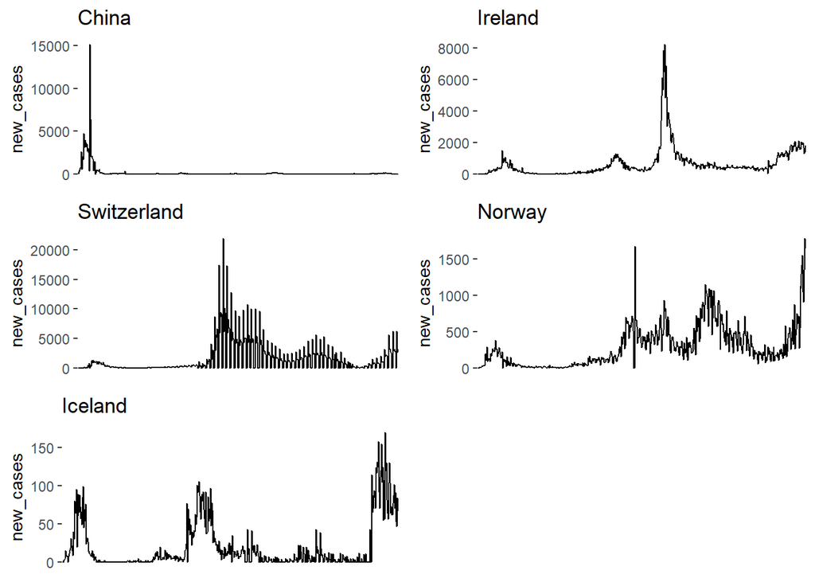

```r
df2 <- subset(newdf,location=="Ireland" | location=="Iceland" | location=="Norway" | location=="Switzerland" | location=="China",select=c(location,population,diabetes_prevalence,cardiovasc_death_rate,male_smokers,female_smokers,total_deaths))
df13<-df2 %>%
  group_by(location) %>%
  summarise_at(vars(population,diabetes_prevalence,cardiovasc_death_rate,male_smokers,female_smokers,total_deaths),list(mean))

iceland <- subset(newdf,location=="Iceland",select = c(date,new_cases))
norway <- subset(newdf,location=="Norway",select = c(date,new_cases))
switz <-subset(newdf,location=="Switzerland",select = c(date,new_cases))
irelane <-subset(newdf,location=="Ireland",select = c(date,new_cases))
china <-subset(newdf,location=="China",select = c(date,new_cases))
df14<- ggplot(data=china,aes(x=date,y=new_cases,group=1))+
  geom_line() +
  labs(title="China")+
  theme(axis.title.x=element_blank(),
        axis.text.x=element_blank(),
        axis.ticks.x=element_blank())
df15<- ggplot(data=irelane,aes(x=date,y=new_cases,group=1))+
  geom_line() +
  labs(title="Ireland")+
  theme(axis.title.x=element_blank(),
        axis.text.x=element_blank(),
        axis.ticks.x=element_blank())
df16<- ggplot(data=switz,aes(x=date,y=new_cases,group=1))+
  geom_line() +
  labs(title="Switzerland")+
  theme(axis.title.x=element_blank(),
        axis.text.x=element_blank(),
        axis.ticks.x=element_blank())
df17<- ggplot(data=norway,aes(x=date,y=new_cases,group=1))+
  geom_line() +
  labs(title="Norway")+
  theme(axis.title.x=element_blank(),
        axis.text.x=element_blank(),
        axis.ticks.x=element_blank())
df18<- ggplot(data=iceland,aes(x=date,y=new_cases,group=1))+
  geom_line() +
  labs(title="Iceland")+
  theme(axis.title.x=element_blank(),
        axis.text.x=element_blank(),
        axis.ticks.x=element_blank())
cowplot::plot_grid(df14,df15,df16,df17,df18, ncol = 2,align = 'h', axis = 'l')
```

**Inference:**  
1. The rate of positive cases has been increasing day by day in norway.  
2. At one moment switzerland effect most than other top 4 developed countries.  
3. China managed to take certain measures to control the rate of cases and that gives a good result as they manages to not increase the rate.  
4. Iceland and Ireland are having peaks and valleys in their postive rate.  
Relation between cases and vaccinations in top 10 healthcare countries

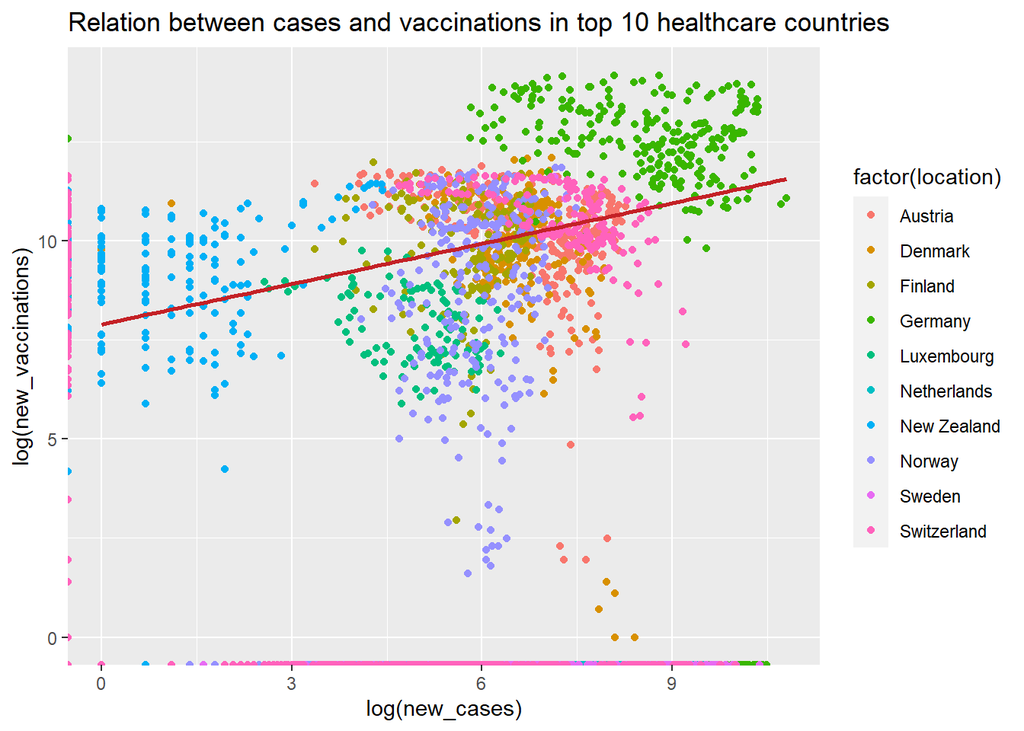

```r
df143 <- subset(newdf,location=="Denmark" | location=="Norway" | location=="Switzerland" | location=="Sweden" | location=="Finland"|location=="Netherlands"|location=="New Zealand"|location=="Germany"|location=="Luxembourg"|location=="Austria", select=c(location,new_cases,new_vaccinations))
ggplot(df143, aes(x = log(new_cases),y = log(new_vaccinations))) +
  geom_point(aes(color = factor(location)))+
  stat_smooth(method = "lm",col = "#C42126",se = FALSE,size = 1)+
  labs(title = "Relation between cases and vaccinations in top 10 healthcare countries")
```

**Inference:**  
1. Vaccination process in germany is going very fast than other countries.  
2. These two variables has a strong bond as the line of best fit suggests a positive relationship.  
3. As the count of cases increases day by day, the countries are managing to speed up the vaccination process.  
Scatter Plot matrix between covid factors and country development indices

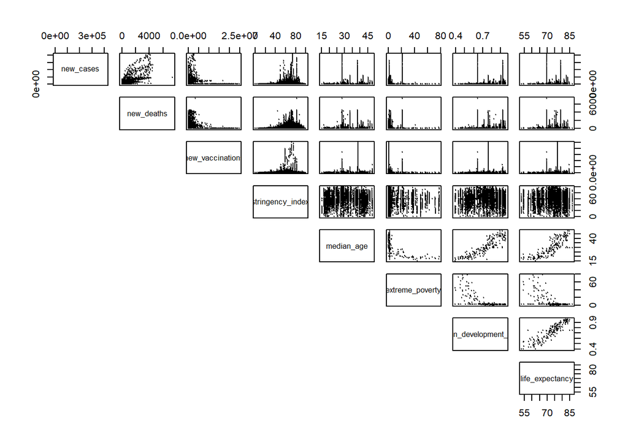

```r
matrixdf<-newdf[, c('new_cases', 'new_deaths','new_vaccinations','stringency_index','median_age','extreme_poverty',
                   'human_development_index','life_expectancy')]
plot(matrixdf , pch = 19, lower.panel = NULL,cex=0.0000000000001,col="black")
```

**Inference:**  
1. As the vaccination progress increases, Deaths and cases are decreasing.  
2.As the stringency index increases, vaccinations are increasing.  
3.As the Extreme Poverty Increases, Vaccinations are decreasing.  
Scatter Plot matrix between covid factors and different health death rates.

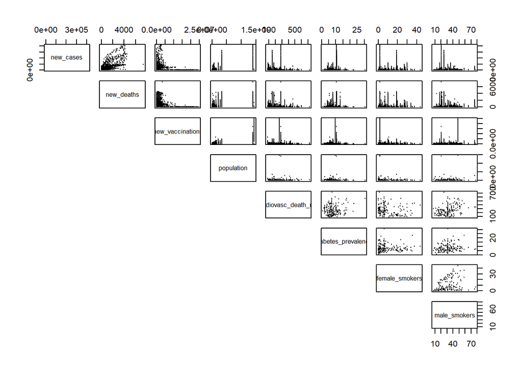

```r
matrixdf<-newdf[, c('new_cases', 'new_deaths','new_vaccinations','population','cardiovasc_death_rate','diabetes_prevalence',
                    'female_smokers','male_smokers')]
plot(matrixdf , pch = 19, lower.panel = NULL,cex=0.0000000000001,col="black")
```

**Inference:**  
1.As the population increases, Cases,deaths,vaccinations are increasing.  
2. As the Cardiovascular death rate and diabetes prevalence are increasing, vaccinations,deaths and cases are increasing upto some point and decreasing after then. Since it is a rate, it depends on population. So, we can say vaccinations,deaths and cases were increasing.

Correlation between Cases, Deaths and Vaccinations

```r
data2<-newdf %>%
  select(new_cases,new_deaths,new_vaccinations)
round(cor(data2),digits = 2)
```

```
##                  new_cases new_deaths new_vaccinations
## new_cases             1.00       0.80             0.13
## new_deaths            0.80       1.00             0.12
## new_vaccinations      0.13       0.12             1.00
```

**Inference:**  
1. the correlation between cases and deaths are high.  
2. The correlation between cases and vaccinations is 0.13 which is almost equal to zero.This indicates they have low positive correlation.  
3. The correlation between deaths and vaccinations is 0.12 which is almost equal to zero.This indicates they have low positive correlation.  
Pearson Correlation between Cases and Vaccinations

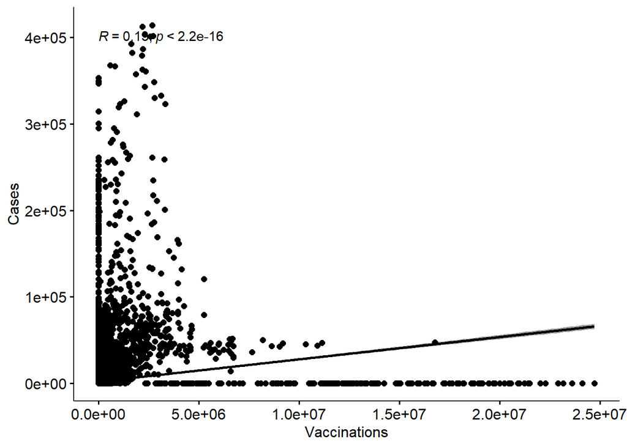

```r
ggscatter(data2, x = "new_vaccinations", y = "new_cases",
          add = "reg.line", conf.int = TRUE,
          cor.coef = TRUE, cor.method = "pearson",
          xlab = "Vaccinations", ylab = "Cases")
```

**Inference:**  
1.The value of pearson coefficient is 0.13 which suggests us that it has low positive correlation between those variables  
Pearson Correlation between deaths and Vaccinations

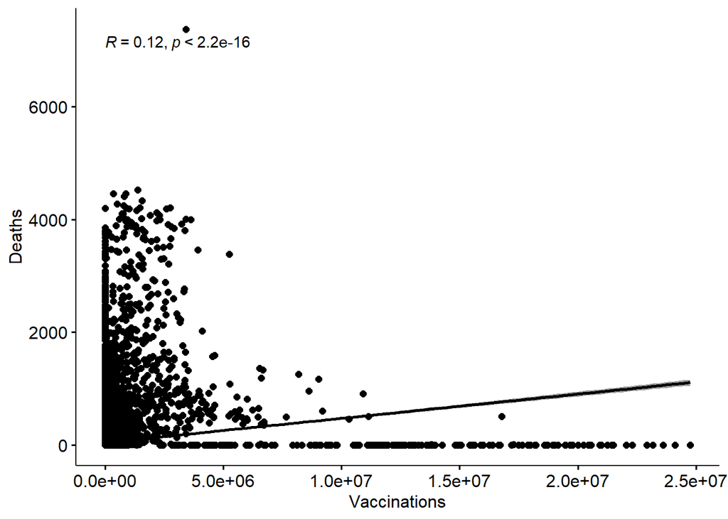

```r
ggscatter(data2, x = "new_vaccinations", y = "new_deaths",
          add = "reg.line", conf.int = TRUE,
          cor.coef = TRUE, cor.method = "pearson",
          xlab = "Vaccinations", ylab = "Deaths")
```

**Inference:**  
1.The value of pearson coefficient is 0.12 which suggests us that it has low positive correlation between those variables  
**Grouping the daily vaccination details of India.**  
Since, we have the data by day wise, we are imputing the total vaccinations

```r
india<-subset(newdf,newdf$location=="India")
india_vaccinations<-india[,c("date","new_vaccinations")]
india_vaccinations$cummulative<-0
for(i in 1:nrow(india_vaccinations)){
  if(i>1){
    india_vaccinations$cummulative[i]<-india_vaccinations$new_vaccinations[i] + india_vaccinations$cummulative[i-1]
  }
  else{
    india_vaccinations$cummulative[i]<-india_vaccinations$new_vaccinations[i]
  }
}
```

**Using ARIMA model to predict the day, at which India will be fully vaccinated.**

```r
library(forecast)
vec<-india_vaccinations$cummulative
inds <- seq(as.Date("2020-02-01"), as.Date("2021-09-01"), by = "day")
#inds[581]
data<-ts(vec,start=c(2020, as.numeric(format(inds[1], "%j"))),frequency=365)
fit <- auto.arima(data)
num1<-predict(fit,365)
num1
```

```
## $pred
## Time Series:
## Start = c(2021, 248)
## End = c(2022, 247)
## Frequency = 365
##   [1]  601378960  610465263  619551567  628637870  637724173  646810476
##   [7]  655896780  664983083  674069386  683155689  692241993  701328296
##  [13]  710414599  719500902  728587206  737673509  746759812  755846115
##  [19]  764932419  774018722  783105025  792191328  801277632  810363935
##  [25]  819450238  828536541  837622845  846709148  855795451  864881754
##  [31]  873968058  883054361  892140664  901226967  910313271  919399574
##  [37]  928485877  937572180  946658484  955744787  964831090  973917393
##  [43]  983003697  992090000 1001176303 1010262606 1019348910 1028435213
##  [49] 1037521516 1046607819 1055694123 1064780426 1073866729 1082953032
##  [55] 1092039336 1101125639 1110211942 1119298245 1128384549 1137470852
```

[output cut: 118 more lines]

```r
#start(data)
#end(data)
#cycle(data)
```

**Predicted Forecast**

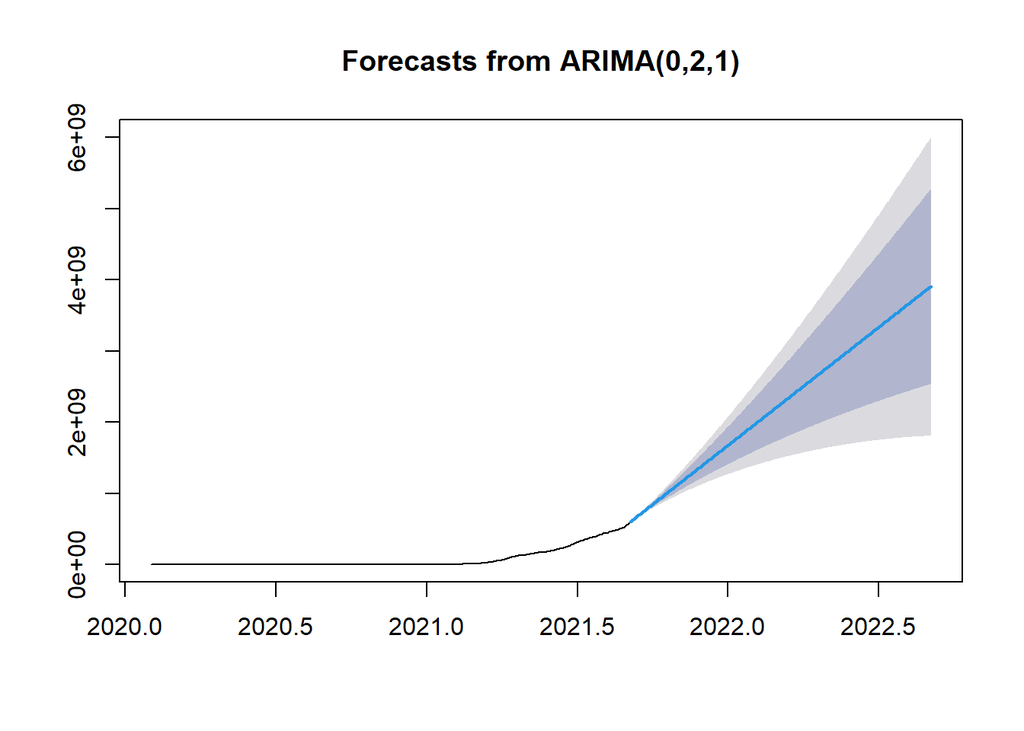

```r
fore <- forecast(fit, h = 365)
plot(fore)
```

**Inference:**  
As, per results vaccinations will be completed at 10th april 2022 and if we included booster doses into count then it will take around one year from 1st september 2022.